# Bayesian state-space SI model with year-specific, smooth seasonality

Andrew Tredennick

15 June, 2018

## The model

The idea is to fit a discrete-time state-space model following susceptible-infected (SI) dynamics. Previous TSIR (time-series SIR) models allowed for seasonality in transmission rate, but that seasonality was shared among all years. This creates problems when attempting to calculating time-varying quantities of interest, such as effective reproductive rate ($R_e$). Here, I will implement a more flexible approach, where seasonality is incorporated with a smooth basis function (spline) that has year-specific parameters.

The model is as follows:

$$y_t \sim \text{Binomial}(I_t, p) \\
I_{t+1} \sim \text{Negative Binomial}\left(\lambda_{t+1}, I_t \right), \\
S_{t+1} = S_t - I_{t+1} + b_t,\\
\lambda_{t+1} = \beta_t I_t^\alpha z_t^\epsilon, \\
\beta_t = \mu_{y(t)} + \sum^J_{j=1} \mathbf{W}\eta_{j,y(t)}, \\
\mu_{y(t)} \sim \text{Normal}(0,1), \\
\eta_{y(t)} \sim \text{Normal}(0,1),$$

| Parameter | Definition |
| --- | --- |
| $I_t$ | Number of infected individuals at time *t* (latent). |
| $S_t$ | Number of susceptible individuals at time *t* (latent). |
| $y_t$ | Number of reported cases at time *t* (observed). |
| $p$ | Reporting fraction. |
| $b_t$ | Number of births at time *t*. |
| $\lambda_t$ | Force of infection at time *t*. |
| $\beta_t$ | Transmission rate at time *t*. |
| $\alpha$ | Something about mixing. |
| $\epsilon$ | Something… |
| $\mu_{y(t)}$ | Mean of the basis function for $\beta$ in year *y* associated with time *t*. |
| $\eta_{j,y(t)}$ | Basis function coefficient for knot *j* in year *y* associated with time *t*. |
| $\mathbf{W}$ | Matrix of basis vectors |

## Fitting the model

I will use a subset of the Niger measles data that come from the capitol, Niamey.

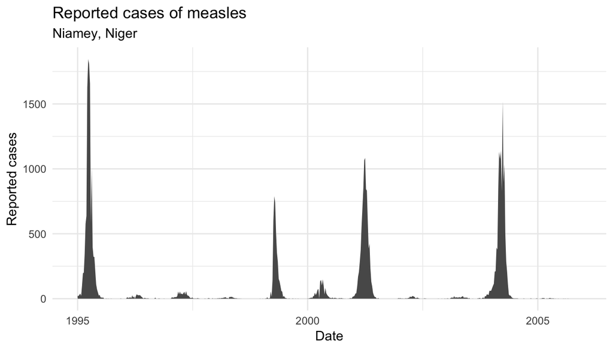

```r
file_name <- "../niger_measles/niger_regional_1995_2005.csv"
niger_measles_raw <- read_csv(file_name, col_types = cols())

num_regions <- nrow(niger_measles_raw)
num_weeks <- ncol(niger_measles_raw) - 1  # subtract 1 from ncol() because first column are regions

# Create a vector of dates for each week over 11 years
start_date <- ymd("19950101")
all_dates <- seq(start_date, by = "week", length.out = num_weeks)

# Clean up the data frame
measles_dat <- niger_measles_raw %>%
  gather(key = week, value = cases, -X1) %>%
  mutate(
    week_num = rep(1:num_weeks, each = num_regions),
    date = rep(all_dates, each = num_regions)
  ) %>%
  dplyr::rename(region = X1) %>%
  dplyr::select(-week) %>%
  filter(region == "Niamey (City)")

# Plot the time series
ggplot(measles_dat, aes(x = date)) +
  geom_ribbon(aes(ymax = cases, ymin = 0), fill = "grey35") +
  labs(x = "Date", y = "Reported cases") +
  ggtitle("Reported cases of measles", subtitle = "Niamey, Niger")
```

There are a couple pre-processing steps necessary before fitting the model:

This seems a little awkward, but here is my plan. We know the estimated annual birth rate in Niger is 50.73 births per 1000 people, or 0.05 per person per year. Assuming this is relatively constant through time, we can apply this rate to annual estimates of the total population in Niamey. Unfortunately, annual population estimates are hard to come by. So, I will fit a linear trend between population estimates and use that trend to estimate population size in unobserved years. I will then multiply the annual per capita birth rate (*r* = 0.05) by the yearly population estimates ($\hat{N_y}$) to obtain the number of births for each year. Then I divide by the number of weeks in a year ($\overline{w}$ = 52.1429 weeks, on average) to arrive at the number of births in each week *t*:

$$b_t = \frac{r \hat{N}_{y(t)}} {\overline{w}},$$

where $y(t)$ reads “year *y* associated week *t*.”

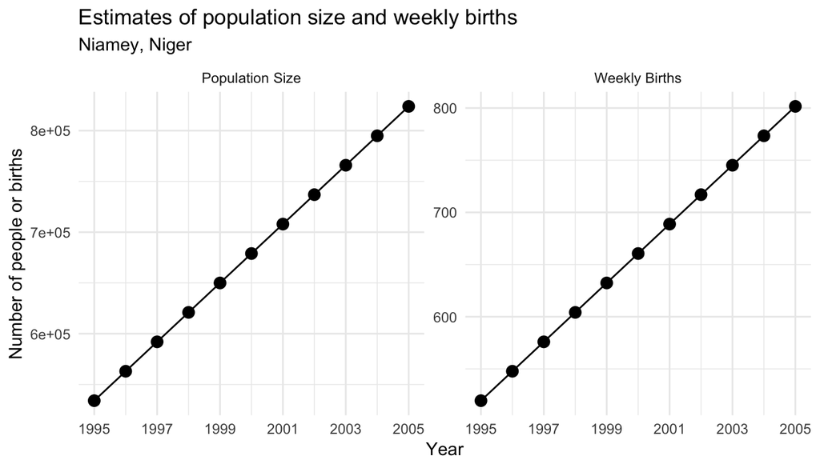

```r
# Estimate population size
niamey_pop <- tibble(
  year = c(2001, 2012),
  population = c(707951, 1026800)  # from UN DATA, via Google
)

poptrend <- lm(population~year, data = niamey_pop)
poppreds <- round(predict(poptrend, newdata = data.frame(year = 1995:2005)))


# Estimate weekly birth rates
percap_birth_rate <- 50.73/1000
avg_weeks <- 52.1429

niamey_pop_preds <- tibble(
  Year = 1995:2005,
  `Population Size` = poppreds
) %>%
  mutate(
    `Weekly Births` = percap_birth_rate * `Population Size` / avg_weeks
  ) %>%
  gather(key = variable, value = value, -Year)


# Plot the estimates
ggplot(niamey_pop_preds, aes(x = Year, y = value)) +
  geom_line() +
  geom_point(size = 3) +
  facet_wrap(~variable, scales = "free_y") +
  scale_x_continuous(breaks = seq(1995,2005,2)) +
  labs(x = "Year", y = "Number of people or births") +
  ggtitle("Estimates of population size and weekly births", subtitle = "Niamey, Niger")
```